# Project 1

Isaac Moore

Loading packages

```r
library("tidyverse")
require(gridExtra)
```

```r
data_path <- "assets/sat_scores.csv"
```

### Step 1: Open the sat_scores.csv file. Investigate the data, and answer the questions below.

**1. What does the data describe?**  
*This data provides mean results for Math and Verbal scores for students taking the SAT in the year 2001, from each state, and the participation rate for each state. This data was taken from the College Board.*

**2. Does the data look complete? Are there any obvious issues with the observations?**  
*The data colected for Math and Verbal are averages for each state, not the actual results - We are not aware of the methods for collecting the dat. The data also contatins a total for each column, which would not return accurate calculations - this summary data will be removed.*

### Step 2: Load the data.

**3. Create a data dictionary for the dataset.**  
*I will instead be loading the data into a dplyr data frame, using the read.csv function*

**4. Load the data into a list of lists**  
*Not necessary…*

**5. Print the data**

```r
data <- tbl_df(read.csv(data_path))
head(data)
```

| State | Rate | Verbal | Math |
| --- | --- | --- | --- |
| CT | 82 | 509 | 510 |
| NJ | 81 | 499 | 513 |
| MA | 79 | 511 | 515 |
| NY | 77 | 495 | 505 |
| NH | 72 | 520 | 516 |
| RI | 71 | 501 | 499 |

```r
tail(data)
```

| State | Rate | Verbal | Math |
| --- | --- | --- | --- |
| UT | 5 | 575 | 570 |
| IA | 5 | 593 | 603 |
| SD | 4 | 577 | 582 |
| ND | 4 | 592 | 599 |
| MS | 4 | 566 | 551 |
| All | 45 | 506 | 514 |

There is a summary observation (row) at the end of the dataset, I will remove the obsevation.

```r
dim(data)
```

```
[1] 52  4
```

```r
data <- data[1:51,]
```

```r
dim(data)
```

```
[1] 51  4
```

**6. Extract a list of the labels from the data, and remove them from the data.**

```r
names(data)
```

```
[1] "State"  "Rate"   "Verbal" "Math"
```

**7. Create a list of State names extracted from the data.**

```r
state_names <- unique(data$State)
state_names
```

```
 [1] CT NJ MA NY NH RI PA VT ME VA DE MD NC GA IN SC DC OR FL WA TX HI AK CA AZ NV CO OH
[29] MT WV ID TN NM IL KY WY MI MN KS AL NB OK MO LA WI AR UT IA SD ND MS
52 Levels: AK AL All AR AZ CA CO CT DC DE FL GA HI IA ID IL IN KS KY LA MA MD ME ... WY
```

**8. Print the types of each column**

```r
str(data)
```

```
Classes ‘tbl_df’, ‘tbl’ and 'data.frame':   51 obs. of  4 variables:
 $ State : Factor w/ 52 levels "AK","AL","All",..: 8 33 21 36 32 41 40 48 23 47 ...
 $ Rate  : int  82 81 79 77 72 71 71 69 69 68 ...
 $ Verbal: int  509 499 511 495 520 501 500 511 506 510 ...
 $ Math  : int  510 513 515 505 516 499 499 506 500 501 ...
```

**9. Do any types need to be reassigned? If so, go ahead and do it.**  
*Nope, Factor works for the State column - Considered converting to character, but not necessary. Integer is fine for observations in Rate, Verbal, and Math.*

**10. Create a dictionary for each column mapping the State to its respective value for that column.**  
A dictionary in Python is equivalent to a list in R.

```r
data_list = list(State = data$State, Rate = data$Rate, Verbal = data$Verbal, Math = data$Math)
data_list
```

```
$State
 [1] CT NJ MA NY NH RI PA VT ME VA DE MD NC GA IN SC DC OR FL WA TX HI AK CA AZ NV CO OH
[29] MT WV ID TN NM IL KY WY MI MN KS AL NB OK MO LA WI AR UT IA SD ND MS
52 Levels: AK AL All AR AZ CA CO CT DC DE FL GA HI IA ID IL IN KS KY LA MA MD ME ... WY

$Rate
 [1] 82 81 79 77 72 71 71 69 69 68 67 65 65 63 60 57 56 55 54 53 53 52 51 51 34 33 31 26
[29] 23 18 17 13 13 12 12 11 11  9  9  9  8  8  8  7  6  6  5  5  4  4  4

$Verbal
 [1] 509 499 511 495 520 501 500 511 506 510 501 508 493 491 499 486 482 526 498 527 493
[22] 485 514 498 523 509 539 534 539 527 543 562 551 576 550 547 561 580 577 559 562 567
[43] 577 564 584 562 575 593 577 592 566

$Math
 [1] 510 513 515 505 516 499 499 506 500 501 499 510 499 489 501 488 474 526 499 527 499
[22] 515 510 517 525 515 542 439 539 512 542 553 542 589 550 545 572 589 580 554 568 561
[43] 577 562 596 550 570 603 582 599 551
```

**11. Create a dictionary with the values for each of the numeric columns**

```r
data_list_numeric = list(Rate = data$Rate, Verbal = data$Verbal, Math = data$Math)
data_list_numeric
```

```
$Rate
 [1] 82 81 79 77 72 71 71 69 69 68 67 65 65 63 60 57 56 55 54 53 53 52 51 51 34 33 31 26
[29] 23 18 17 13 13 12 12 11 11  9  9  9  8  8  8  7  6  6  5  5  4  4  4

$Verbal
 [1] 509 499 511 495 520 501 500 511 506 510 501 508 493 491 499 486 482 526 498 527 493
[22] 485 514 498 523 509 539 534 539 527 543 562 551 576 550 547 561 580 577 559 562 567
[43] 577 564 584 562 575 593 577 592 566

$Math
 [1] 510 513 515 505 516 499 499 506 500 501 499 510 499 489 501 488 474 526 499 527 499
[22] 515 510 517 525 515 542 439 539 512 542 553 542 589 550 545 572 589 580 554 568 561
[43] 577 562 596 550 570 603 582 599 551
```

### Step 3: Describe the data

**12. Print the min and max of each column**

```r
cat("Rate min", min(data$Rate), "- Rate max", max(data$Rate), "\n")
```

```
Rate min 4 - Rate max 82
```

```r
cat("Verbal min", min(data$Verbal), "- Verbal max", max(data$Verbal), "\n")
```

```
Verbal min 482 - Verbal max 593
```

```r
cat("Math min", min(data$Math), "- Math max", max(data$Math), "\n")
```

```
Math min 439 - Math max 603
```

**13. Write a function using only list comprehensions, no loops, to compute Standard Deviation. Print the Standard Deviation of each numeric column.**  
Since there is no list comprehension in R - I’m just going to write a normal funciton.

```r
my_std <- function(x){
        n <- length(x)
        return(sqrt(sum((x - mean(x))^2) / (n - 1)))
}
my_std(data$Rate)
```

```
[1] 27.55068
```

```r
sd(data$Rate)
```

```
[1] 27.55068
```

```r
my_std(data$Verbal)
```

```
[1] 33.36067
```

```r
sd(data$Verbal)
```

```
[1] 33.36067
```

```r
my_std(data$Math)
```

```
[1] 36.28739
```

```r
sd(data$Math)
```

```
[1] 36.28739
```

### Step 4: Visualize the data

**14. Using MatPlotLib and PyPlot, plot the distribution of the Rate using histograms.** I’ll use ggplot instsead of using Matplotlib or PyPlot

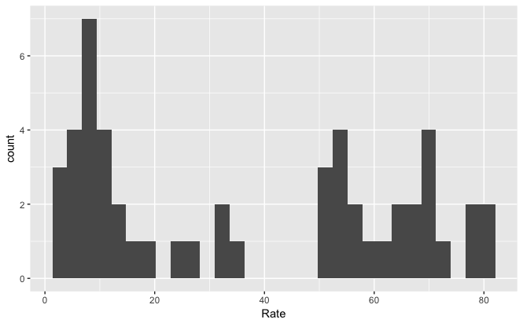

```r
ggplot(data, aes(Rate)) + geom_histogram(bins=30)
```

**15. Plot the Math distribution**

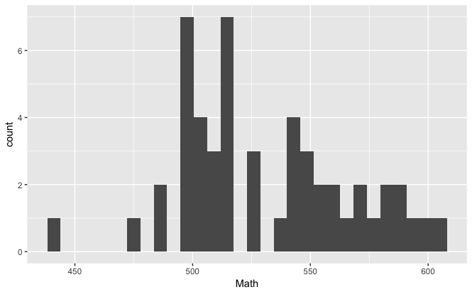

```r
ggplot(data, aes(Math)) + geom_histogram(bins=30)
```

**16. Plot the Verbal distribution**

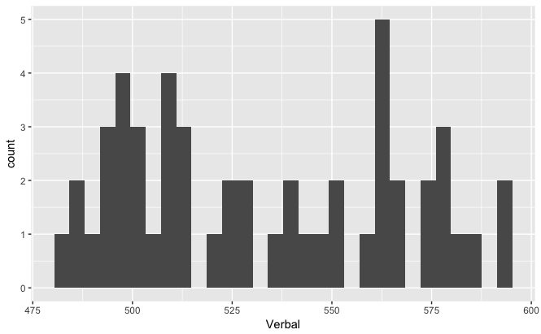

```r
ggplot(data, aes(Verbal)) + geom_histogram(bins=30)
```

**17. What is the typical assumption for data distribution?**  
Since the data, Verbal and Math are mean results from each state the expectation is that we would see a normal distribution (or Gaussian).

**18. Does that distribution hold true for our data?**  
This does not hold true for our data - the Math and Verbal histograms above are not normal distributions.

**19. Plot some scatterplots. BONUS: Use a PyPlot figure to present multiple plots at once.**

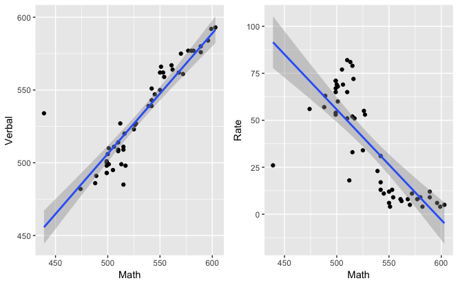

```r
require(gridExtra)
g_MV <- ggplot(data, aes(Math, Verbal)) + geom_point() + geom_smooth(method = lm)
g_MR <- ggplot(data, aes(Math, Rate)) + geom_point() + geom_smooth(method = lm)
grid.arrange(g_MV, g_MR, ncol=2)
```

**20. Are there any interesting relationships to note?**  
There is a correlation between rate to verbal and math - the higher the rate, the lower the average score. This means the more people that took the SAT from each state, the lower the average score was. There is also a positive correlation between high scores on Math and high scores on Verbal. This means, on average that a high score on Math (or Verbal) will result in a high score on Verbal (or Math), respectively.

**21. Create box plots for each variable.**

```r
par(mfrow=c(1,3))
boxplot(data$Rate, main = "Rate")
boxplot(data$Verbal, main = "Verbal")
```

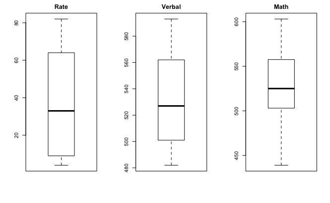

```r
boxplot(data$Math, main = "Math")
```